title: “Mini_Project_52_Solutions” author: “Vannessa Juarez” date: “2020 M11 12” output: html_document: df_print: paged

```r
#import the libraries
library(factoextra)
```

```r
library(datasets)
library(corrplot)
library(caret)
library(ISLR)
library(psych)
library(elasticnet)
library(pls)
```

## `State` dataset from `datasets` in R

```r
#import the data and correctly label the columns
state_data=as.data.frame(state.x77)
attach(state_data)
colnames(state_data)
```

```
## [1] "Population" "Income"     "Illiteracy" "Life Exp"   "Murder"
## [6] "HS Grad"    "Frost"      "Area"
```

```r
colnames(state_data)[4] <- "LifeExp"
colnames(state_data)[6] <- "HsGrad"
colnames(state_data)
```

```
## [1] "Population" "Income"     "Illiteracy" "LifeExp"    "Murder"
## [6] "HsGrad"     "Frost"      "Area"
```

### EDA

Boxplots and histograms usually are plotted to show the distribution of the variables in the dataset. In order to access the normality of the data, a Histogram and boxplot of the variable are constructed and investigated. The boxplots and histograms plotted indicated slight skewness in the data that requires normalizing.

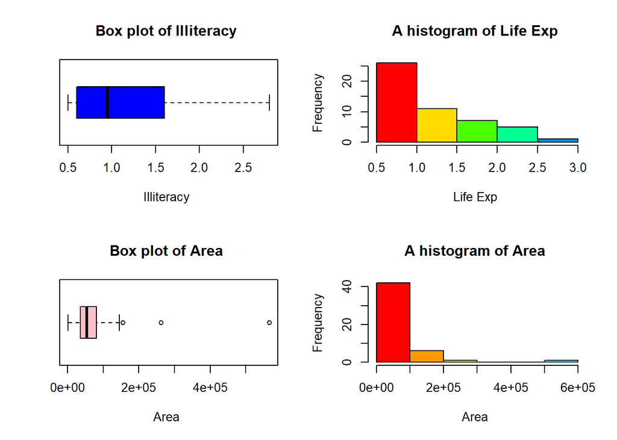

```r
#Exploring the data using histogram and boxplots
par(mfrow=c(2,2))
boxplot(state_data$Illiteracy  , col="blue" , xlab="Illiteracy ",main="Box plot of Illiteracy ", horizontal=TRUE)
hist(state_data$Illiteracy ,col = rainbow(7),xlab="Life Exp ",main="A histogram of Life Exp ")
boxplot(state_data$Area  , col="pink" , xlab="Area ",main="Box plot of Area ", horizontal=TRUE)
hist(state_data$Area ,col = rainbow(10),xlab="Area ",main="A histogram of Area ")
```

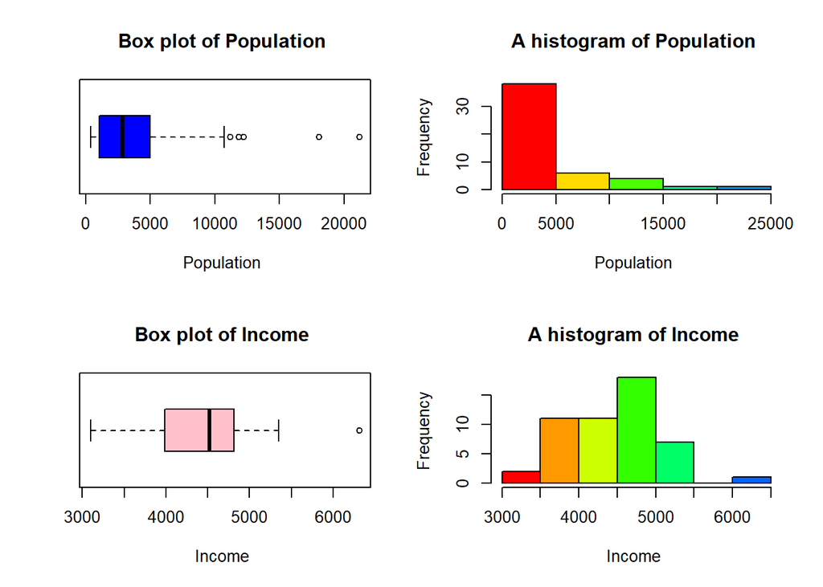

```r
par(mfrow=c(2,2))
boxplot(state_data$Population  , col="blue" , xlab="Population ",main="Box plot of Population ", horizontal=TRUE)
hist(state_data$Population ,col = rainbow(7),xlab="Population ",main="A histogram of Population ")
boxplot(state_data$Income  , col="pink" , xlab="Income ",main="Box plot of Income ", horizontal=TRUE)
hist(state_data$Income ,col = rainbow(10),xlab="Income ",main="A histogram of Income ")
```

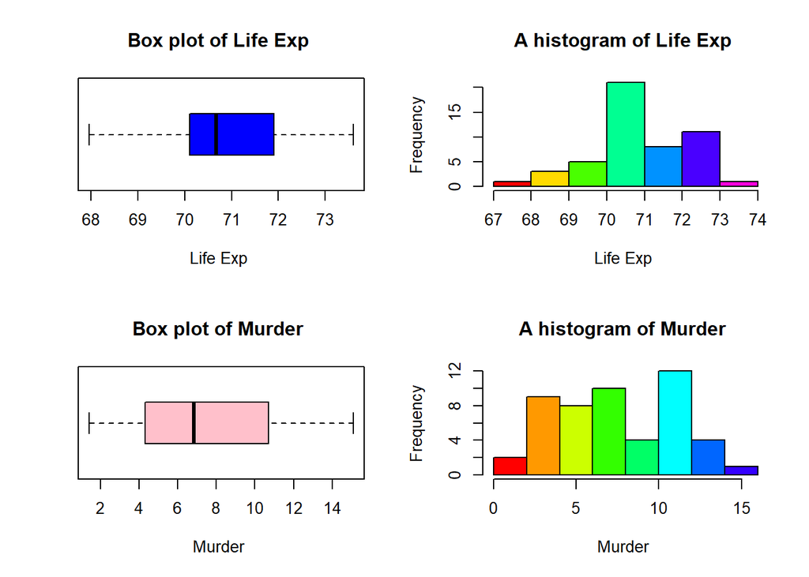

```r
par(mfrow=c(2,2))
boxplot(state_data$LifeExp  , col="blue" , xlab="Life Exp ",main="Box plot of Life Exp ", horizontal=TRUE)
hist(state_data$LifeExp ,col = rainbow(7),xlab="Life Exp ",main="A histogram of Life Exp ")
boxplot(state_data$Murder  , col="pink" , xlab="Murder ",main="Box plot of Murder ", horizontal=TRUE)
hist(state_data$Murder ,col = rainbow(10),xlab="Murder ",main="A histogram of Murder ")
```

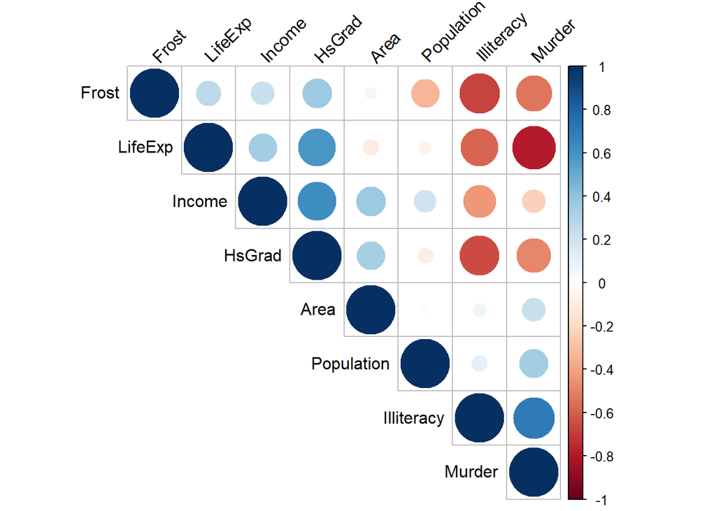

```r
#correlation matrix of the data
par(mfrow=c(1,1))
#explicit call the package
res <- cor(state_data)
corrplot::corrplot(res, type = "upper", order = "hclust",
         tl.col = "black", tl.srt = 45)
```

Standardizing is recomended. Standardizing the variables would place the variables in a standard range that would facilitate analysis and probably reduce the number of extreme outliers.

### PCA analysis

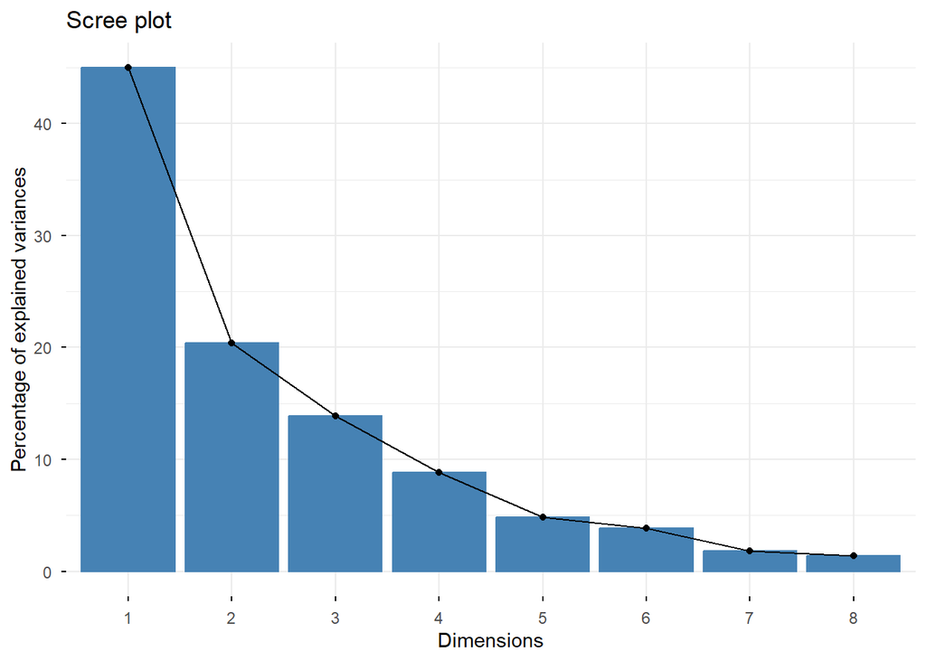

```r
#PACF analysis
PACS <- prcomp(state_data, scale = TRUE)
fviz_eig(PACS)
```

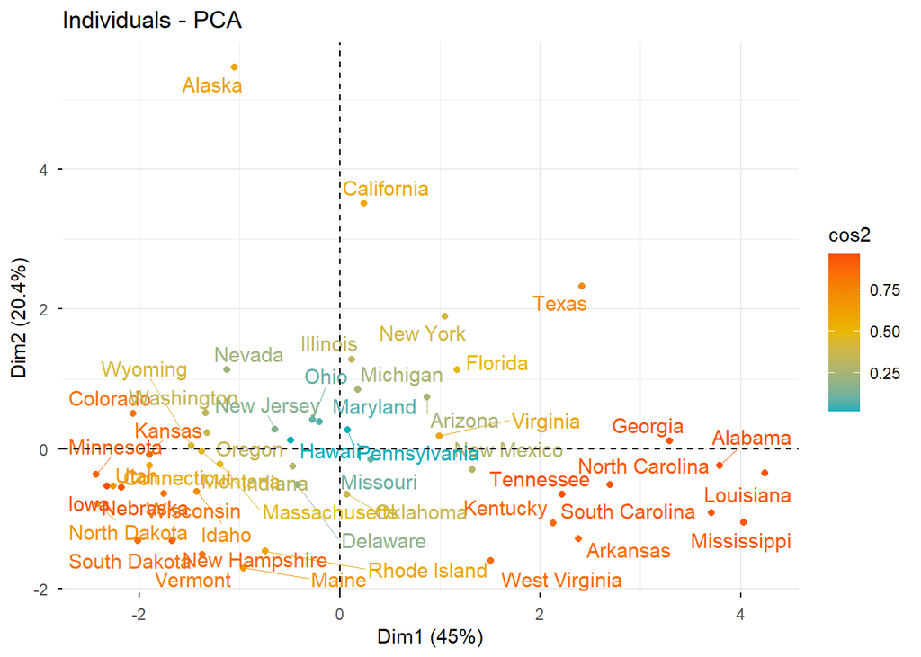

```r
#Visualizing the clusters
fviz_pca_ind(PACS,
             col.ind = "cos2", # Color by the quality of representation
             gradient.cols = c("#00AFBB", "#E7B800", "#FC4E07"),
             repel = TRUE     # Avoid text overlapping
)
```

```r
#obtaining the clusters and score matrix
PACS$rotation
```

```
##                    PC1         PC2         PC3         PC4          PC5
## Population  0.12642809  0.41087417 -0.65632546 -0.40938555 -0.405946365
## Income     -0.29882991  0.51897884 -0.10035919 -0.08844658  0.637586953
## Illiteracy  0.46766917  0.05296872  0.07089849  0.35282802 -0.003525994
## LifeExp    -0.41161037 -0.08165611 -0.35993297  0.44256334 -0.326599685
## Murder      0.44425672  0.30694934  0.10846751 -0.16560017  0.128068739
## HsGrad     -0.42468442  0.29876662  0.04970850  0.23157412  0.099264551
## Frost      -0.35741244 -0.15358409  0.38711447 -0.61865119 -0.217363791
## Area       -0.03338461  0.58762446  0.51038499  0.20112550 -0.498506338
##                    PC6          PC7         PC8
## Population  0.01065617  0.062158658  0.21924645
## Income     -0.46177023 -0.009104712 -0.06029200
## Illiteracy -0.38741578  0.619800310  0.33868838
## LifeExp    -0.21908161  0.256213054 -0.52743331
## Murder      0.32519611  0.295043151 -0.67825134
## HsGrad      0.64464647  0.393019181  0.30724183
## Frost      -0.21268413  0.472013140 -0.02834442
## Area       -0.14836054 -0.286260213 -0.01320320
```

```r
dim(PACS$x)
```

```
## [1] 50  8
```

```r
head(PACS$x)
```

```
##                   PC1        PC2         PC3         PC4          PC5
## Alabama     3.7898873 -0.2347790  0.22931743  0.38326898  0.247550385
## Alaska     -1.0531355  5.4561751  4.24059040  0.57567370 -0.109132365
## Arizona     0.8674288  0.7450615  0.07726865  1.71884320  0.559754776
## Arkansas    2.3817776 -1.2883437  0.22279282  0.62320735 -0.647476204
## California  0.2413815  3.5095228 -2.80644077 -0.07037552 -0.968568143
## Colorado   -2.0621814  0.5056639  0.51138416 -0.10992258 -0.002308581
##                   PC6         PC7        PC8
## Alabama     0.4341035 -0.05725139 -0.5349164
## Alaska     -1.0012994 -0.30217509  0.1184846
## Arizona     0.3049795 -0.13072438  0.5245519
## Arkansas   -0.2587292 -0.03390997 -0.4877230
## California  0.6512877 -0.04531950  0.2573820
## Colorado    0.2662263  0.64411971 -0.3750166
```

Focusing on the first two PCs:

Explained variance in Principle component analysis give the variance accounted for by each fitted cluster. the larger the variance the significant the cluster is. Clusters that explain just a small variance can be dropped since they do not explain any significant variance in the data.

```r
#variance explained
variance_explained <- PACS$sdev^2
pve <- variance_explained/sum(variance_explained)
pve
```

```
## [1] 0.44986195 0.20398990 0.13899264 0.08843803 0.04808021 0.03843271 0.01805610
## [8] 0.01414846
```

```r
cumsum(pve)
```

```
## [1] 0.4498619 0.6538519 0.7928445 0.8812825 0.9293627 0.9677954 0.9858515
## [8] 1.0000000
```

A possible of four clusters can be extracted from the data since ath the fouth cluster the variance explained does not change significantly.

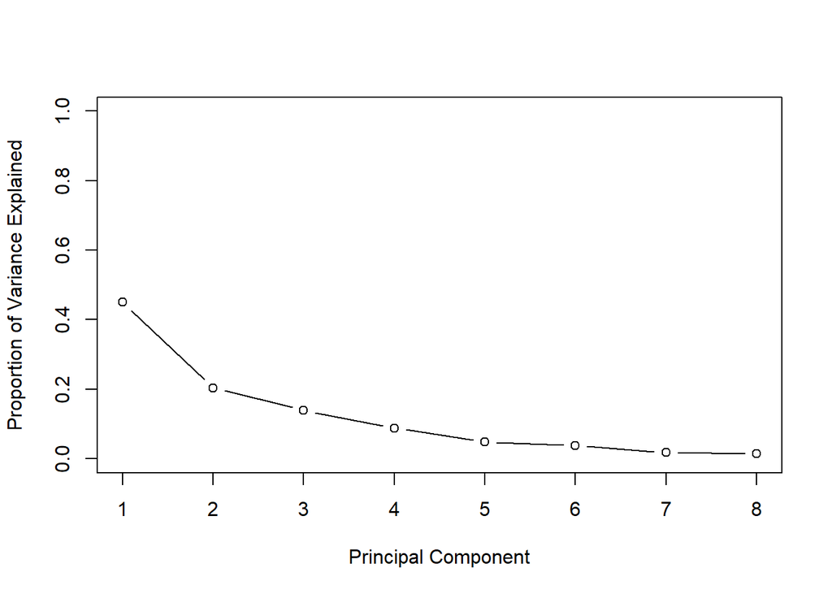

```r
plot(pve, xlab = "Principal Component", ylab = "Proportion of Variance Explained", ylim = c(0,1), type = 'b')
```

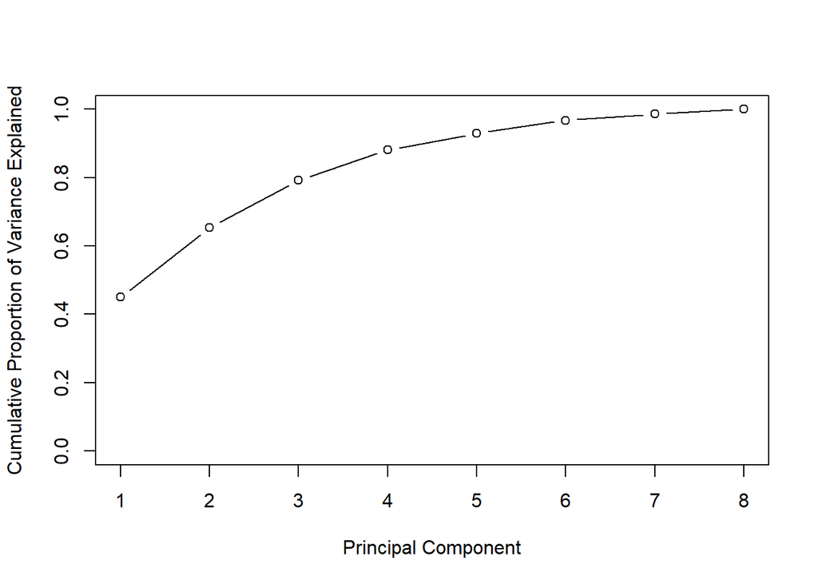

```r
plot(cumsum(pve), xlab = "Principal Component", ylab = "Cumulative Proportion of Variance Explained", ylim = c(0,1), type = 'b')
```

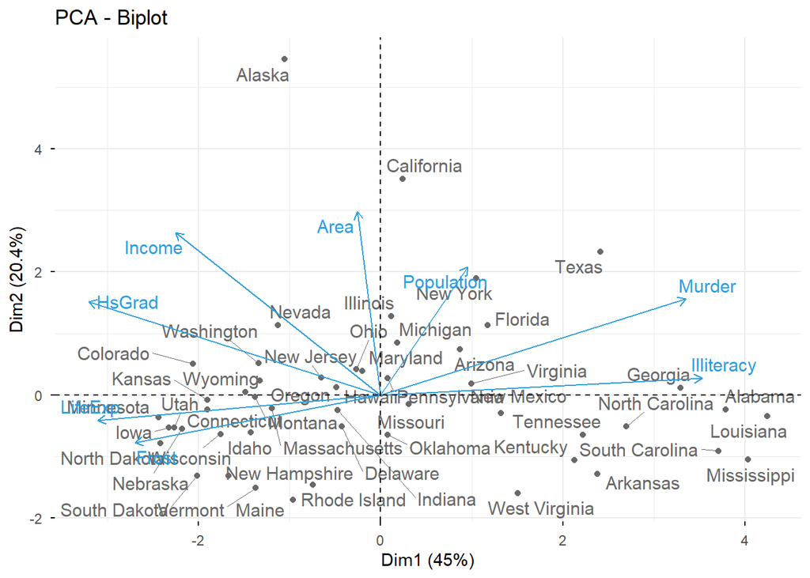

```r
fviz_pca_biplot(PACS, repel = TRUE,
                col.var = "#2E9FDF", # Variables color
                col.ind = "#696969"  # Individuals color
                )
```

## `College` data from the `ISLR` package

```r
#import the data
college_data=as.data.frame(College)
colnames(college_data)
```

```
##  [1] "Private"     "Apps"        "Accept"      "Enroll"      "Top10perc"
##  [6] "Top25perc"   "F.Undergrad" "P.Undergrad" "Outstate"    "Room.Board"
## [11] "Books"       "Personal"    "PhD"         "Terminal"    "S.F.Ratio"
## [16] "perc.alumni" "Expend"      "Grad.Rate"
```

### Fitting a linear model using LSR and report the LOOCV estimate of the test error

The error rate of a fitted model is explained by the RMSE and MAE. the larges these scores are, the poor the model. the lower the MAE and RMSE score the better the model.

```r
#linear model using least squares
model_lm=train(Enroll ~ ., method = "lm", data = college_data, trControl = trainControl(method = "LOOCV"))
model_lm
```

```
## Linear Regression
##
## 777 samples
##  17 predictor
##
## No pre-processing
## Resampling: Leave-One-Out Cross-Validation
## Summary of sample sizes: 776, 776, 776, 776, 776, 776, ...
## Resampling results:
##
##   RMSE     Rsquared   MAE
##   215.795  0.9460842  112.4297
##
## Tuning parameter 'intercept' was held constant at a value of TRUE
```

```r
lm.pred <- predict(model_lm, s = bestlam, newx = as.matrix(college_data[,-4]))
head(lm.pred)
```

```
## Abilene Christian University           Adelphi University
##                     581.2225                     633.5594
##               Adrian College          Agnes Scott College
##                     338.1373                     244.0170
##    Alaska Pacific University            Albertson College
##                      35.5745                     217.1272
```

```r
diffrence=(college_data[4] - as.data.frame(lm.pred))^2
sqrt(mean(diffrence$Enroll))
```

```
## [1] 197.9881
```

```r
paste("The Estimated Test Error = ",sqrt(mean(diffrence$Enroll)))
```

```
## [1] "The Estimated Test Error =  197.988065189166"
```

### Fitting a ridge regression model with chosen lamda chosen by LOOCV

```r
#ridge regression model
controls <- trainControl(method = "LOOCV")

ridgeFit <- train(Enroll ~ ., data = college_data,method = 'ridge',
                  preProc = c("center", "scale"),trControl = controls)
ridgeFit
```

```
## Ridge Regression
##
## 777 samples
##  17 predictor
##
## Pre-processing: centered (17), scaled (17)
## Resampling: Leave-One-Out Cross-Validation
## Summary of sample sizes: 776, 776, 776, 776, 776, 776, ...
## Resampling results across tuning parameters:
##
##   lambda  RMSE      Rsquared   MAE
##   0e+00   215.7950  0.9460842  112.4297
##   1e-04   215.8013  0.9460816  112.4060
##   1e-01   245.5449  0.9343117  121.5970
##
## RMSE was used to select the optimal model using the smallest value.
## The final value used for the model was lambda = 0.
```

```r
ridge.pred <- predict(ridgeFit, s = bestlam, newx = as.matrix(college_data[,-4]))
head(ridge.pred)
```

```
## Abilene Christian University           Adelphi University
##                     581.2225                     633.5594
##               Adrian College          Agnes Scott College
##                     338.1373                     244.0170
##    Alaska Pacific University            Albertson College
##                      35.5745                     217.1272
```

```r
diffrence=(college_data[4] - as.data.frame(ridge.pred))^2
paste("The Estimated Test Error = ",sqrt(mean(diffrence$Enroll)))
```

```
## [1] "The Estimated Test Error =  197.988065189166"
```

### Fitting a lasso model with chosen lamda chosen by LOOCV

```r
#lasso model
lasso_caret<- train(Enroll ~ ., data = college_data, method = "glmnet",
                    trControl=controls,preProc = c("center","scale"),
                    tuneGrid = expand.grid(alpha = 1,
                                           lambda = 0))
lasso_caret
```

```
## glmnet
##
## 777 samples
##  17 predictor
##
## Pre-processing: centered (17), scaled (17)
## Resampling: Leave-One-Out Cross-Validation
## Summary of sample sizes: 776, 776, 776, 776, 776, 776, ...
## Resampling results:
##
##   RMSE      Rsquared   MAE
##   216.0656  0.9459368  111.4636
##
## Tuning parameter 'alpha' was held constant at a value of 1
## Tuning
##  parameter 'lambda' was held constant at a value of 0
```

```r
lasso.pred <- predict(lasso_caret, s = bestlam, newx = as.matrix(college_data[,-4]))
head(lasso.pred)
```

```
## Abilene Christian University           Adelphi University
##                    583.13848                    623.81770
##               Adrian College          Agnes Scott College
##                    339.51403                    236.14603
##    Alaska Pacific University            Albertson College
##                     41.56022                    218.97900
```

```r
diffrence=(college_data[4] - as.data.frame(lasso.pred))^2
paste("The Estimated Test Error = ",sqrt(mean(diffrence$Enroll)))
```

```
## [1] "The Estimated Test Error =  198.097223150227"
```

### Fitting a PCR model with M chosen by LOOCV

```r
#PCR model
model_pcr <- train(
  Enroll~., data = college_data, method = "pcr",
  scale = TRUE,
  trControl = controls,
  tuneLength = 10
)
model_pcr
```

```
## Principal Component Analysis
##
## 777 samples
##  17 predictor
##
## No pre-processing
## Resampling: Leave-One-Out Cross-Validation
## Summary of sample sizes: 776, 776, 776, 776, 776, 776, ...
## Resampling results across tuning parameters:
##
##   ncomp  RMSE      Rsquared     MAE
##    1     928.3504  0.002067205  629.2576
##    2     396.2283  0.817956128  256.6085
##    3     397.4270  0.816880961  258.3156
##    4     341.3964  0.864877989  197.9961
##    5     327.0329  0.876052426  184.5532
##    6     322.2816  0.879634268  180.3194
##    7     323.0602  0.879063249  180.8524
##    8     320.1871  0.881203473  175.5187
##    9     306.8440  0.890931369  160.7769
##   10     304.6308  0.892514893  158.4044
##
## RMSE was used to select the optimal model using the smallest value.
## The final value used for the model was ncomp = 10.
```

```r
pcr.pred <- predict(model_pcr, s = bestlam, newx = as.matrix(college_dhata[,-4]))
head(pcr.pred)
```

```
## [1] 529.28530 524.40198 384.77850 120.14379  21.34879  87.41281
```

```r
diffrence=(college_data[4] - as.data.frame(pcr.pred))^2
paste("The Estimated Test Error = ",sqrt(mean(diffrence$Enroll)))
```

```
## [1] "The Estimated Test Error =  288.489519430283"
```

### Fitting a PLS model with M chosen by LOOCV

```r
#PLS model
model_pls <- train(
  Enroll~., data = college_data, method = "pls",
  scale = TRUE,
  trControl = controls,
  tuneLength = 10
)
model_pls
```

```
## Partial Least Squares
##
## 777 samples
##  17 predictor
##
## No pre-processing
## Resampling: Leave-One-Out Cross-Validation
## Summary of sample sizes: 776, 776, 776, 776, 776, 776, ...
## Resampling results across tuning parameters:
##
##   ncomp  RMSE      Rsquared   MAE
##    1     359.7199  0.8499728  228.0099
##    2     299.0551  0.8963998  171.1950
##    3     279.5408  0.9095462  138.4152
##    4     249.8599  0.9279487  135.6168
##    5     230.6185  0.9386016  115.2865
##    6     220.4408  0.9437857  110.1328
##    7     217.0892  0.9454354  111.2748
##    8     216.5220  0.9457168  111.1761
##    9     216.0825  0.9459443  111.5930
##   10     215.7944  0.9460861  112.5473
##
## RMSE was used to select the optimal model using the smallest value.
## The final value used for the model was ncomp = 10.
```

```r
pls.pred <- predict(model_pls, s = bestlam, newx = as.matrix(college_data[,-4]))
head(pls.pred)
```

```
## [1] 583.04775 642.93657 340.06419 237.78421  41.41868 223.04128
```

```r
diffrence=(college_data[4] - as.data.frame(pls.pred))^2
paste("The Estimated Test Error = ",sqrt(mean(diffrence$Enroll)))
```

```
## [1] "The Estimated Test Error =  198.12600378024"
```

## Planet data set

This dataset gives values of three features for 101 exoplanets discovered up to OCt 2002. The objective of this study is to cluster the exoplanets on the basis of these features.

You may read about them at https://en.wikipedia.org/wiki/Exoplanet. The features recorded are — Mass (in Jupiter mass), Period (in Earth days), and Eccentricity.

```r
#import the data
data=read.csv(file = "C:/Users/Owner/Documents/Rstudio/planet1.csv", header=T)
head(data)
```

```
##    Mass Period Eccentricity
## 1 0.120  4.950         0.00
## 2 0.197  3.971         0.00
## 3 0.210 44.280         0.34
## 4 0.220 75.800         0.28
## 5 0.230  6.403         0.08
## 6 0.250  3.024         0.02
```

```r
describe(data, skew = F)
```

```
##              vars   n   mean     sd median  min     max   range    se
## Mass            1 101   3.33   3.68   1.76 0.05   17.50   17.45  0.37
## Period          2 101 666.53 873.75 337.11 2.98 5360.00 5357.02 86.94
## Eccentricity    3 101   0.28   0.21   0.27 0.00    0.93    0.93  0.02
```

```r
attach(data)
```

### EDA- Univariate and Bivariate

```r
#Exploratory data analysis
par(mfrow=c(1,1))
res1 <- cor(data)
res1
```

```
##                   Mass    Period Eccentricity
## Mass         1.0000000 0.2684085    0.3049333
## Period       0.2684085 1.0000000    0.1445935
## Eccentricity 0.3049333 0.1445935    1.0000000
```

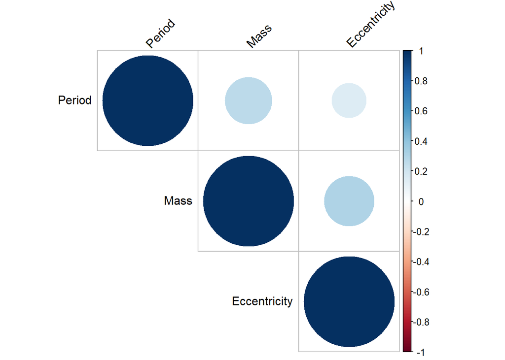

```r
corrplot::corrplot(res1, type = "upper", order = "hclust",
         tl.col = "black", tl.srt = 45)
```

```r
describe(data$Period, skew = F)
```

```
##    vars   n   mean     sd median  min  max   range    se
## X1    1 101 666.53 873.75 337.11 2.98 5360 5357.02 86.94
```

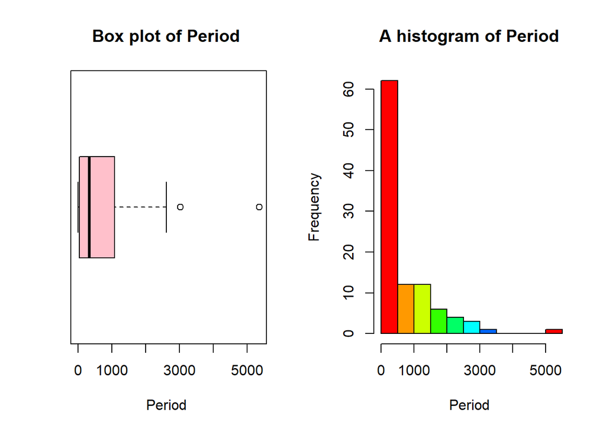

```r
par(mfrow=c(1,2))
boxplot(data$Period  , col="pink" , xlab="Period ",main="Box plot of Period ", horizontal=TRUE)
hist(data$Period ,col = rainbow(10),xlab="Period ",main="A histogram of Period ")
```

```r
describe(data$Eccentricity)
```

```
##    vars   n mean   sd median trimmed  mad min  max range skew kurtosis   se
## X1    1 101 0.28 0.21   0.27    0.27 0.24   0 0.93  0.93 0.51    -0.39 0.02
```

```r
describe(data$Mass)
```

```
##    vars   n mean   sd median trimmed  mad  min  max range skew kurtosis   se
## X1    1 101 3.33 3.68   1.76    2.62 1.81 0.05 17.5 17.45 1.82     3.15 0.37
```

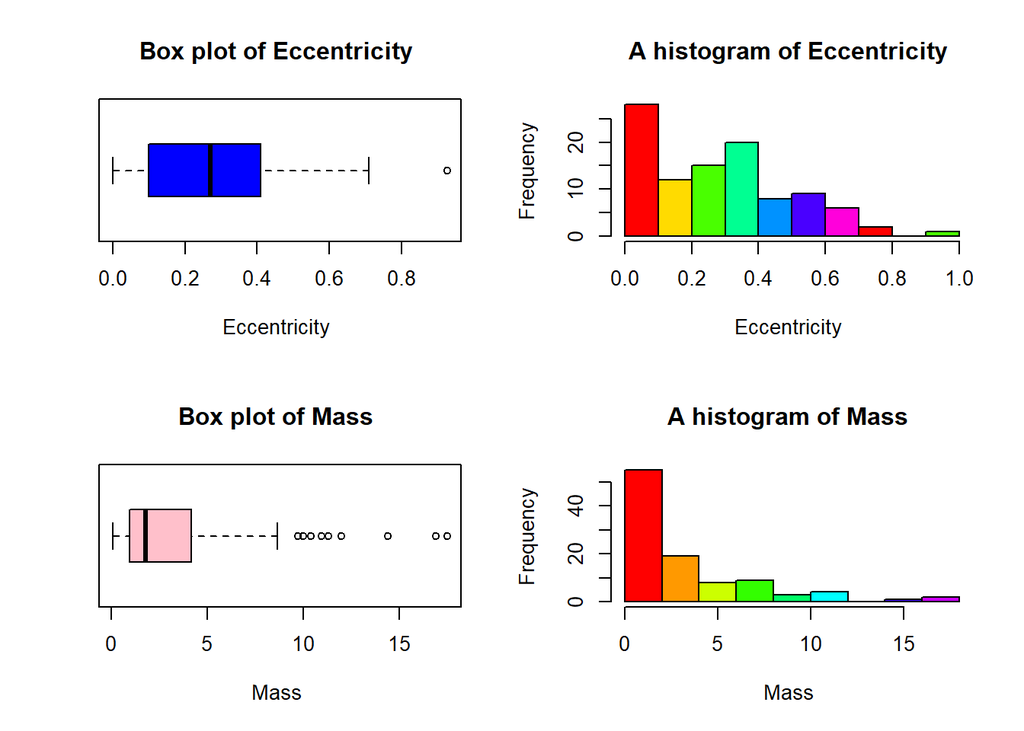

```r
par(mfrow=c(2,2))
boxplot(data$Eccentricity  , col="blue" , xlab="Eccentricity ",main="Box plot of Eccentricity ", horizontal=TRUE)
hist(data$Eccentricity ,col = rainbow(7),xlab="Eccentricity ",main="A histogram of Eccentricity ")
boxplot(data$Mass  , col="pink" , xlab="Mass ",main="Box plot of Mass ", horizontal=TRUE)
hist(data$Mass ,col = rainbow(10),xlab="Mass ",main="A histogram of Mass ")
```

Both the variables Mass and Eccentricity exhibits positive skewness as indicated by the histograms and the boxplots. The Eccentricity variables has a mean of of 0.28 and a standard deviation of 0.21. The Mass variable has a mean of 3.33 and a standard deviation of 3.68

### Is standardizing effective?

Yes. standardizing the variables would normalize the data. additionally standardizing the data is useful to attain internal consistency of the data to have the same content and format. The data set have units that have different variables with different units, thus standardizing the data is essential. Standardizing is essential when we analyze using distance based methods.

### Standardizationusing complete linkage and Euclidean distance

Metric based distance since the variables in the data do not have high correlations. Correlation based distance assumes that the highly correlated variables to be same in distance.

### Summarize the cluster specific means

```r
#scaling the data
data=as.data.frame(scale(data))

hc.single <- hclust(dist(data), method = "single")
hc.complete <- hclust(dist(data), method = "complete")
hc.average <- hclust(dist(data), method = "average")
```

A dendrogram is a diagram that shows the hierarchical relationship between objects.

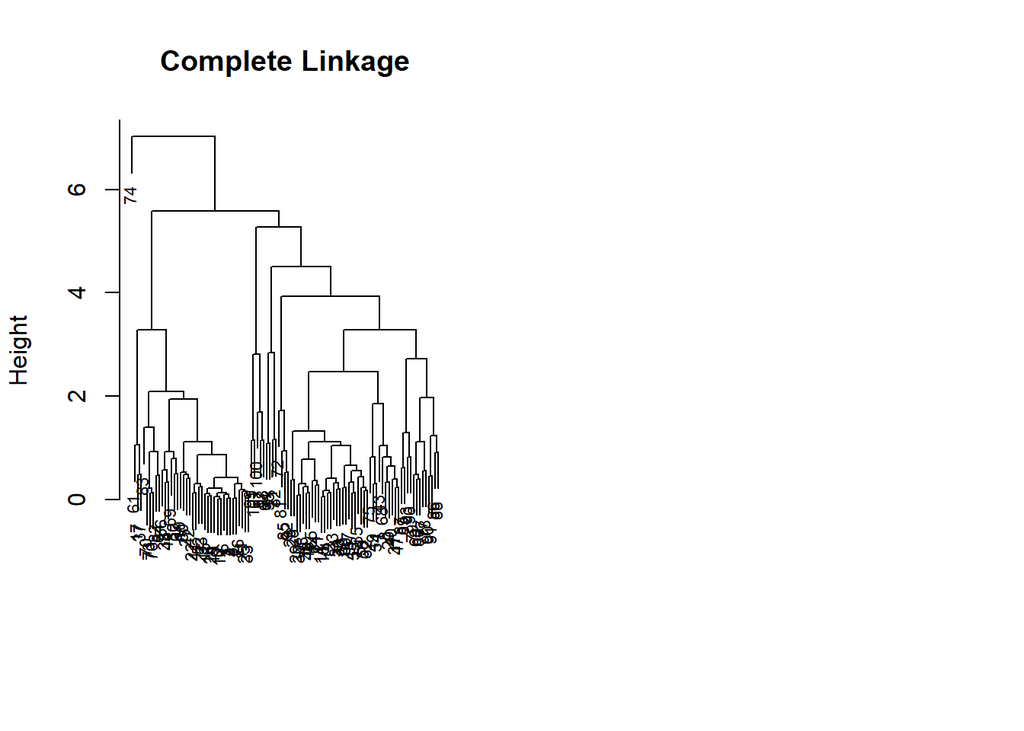

```r
#plotting the dendograms
par(mfrow = c(1, 2))
plot(hc.complete, main = "Complete Linkage", xlab = "", sub = "",
     cex = 0.7)
```

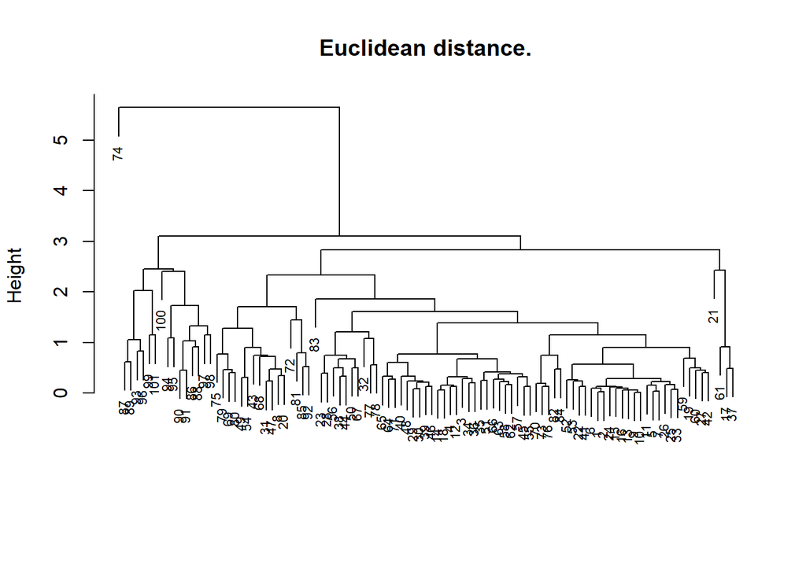

```r
plot(hc.average, main = "Euclidean distance.", xlab = "", sub = "", cex = 0.7)
```

```r
cutree(hc.complete, 3)
```

```
##   [1] 1 1 2 2 1 1 1 2 1 1 1 2 1 2 1 1 1 2 1 2 2 1 2 1 1 1 1 2 2 2 2 2 1 2 2 2 1
##  [38] 1 2 2 1 1 2 1 2 2 2 2 2 1 2 1 1 2 2 1 2 2 1 1 1 2 2 2 2 2 1 2 2 1 2 2 1 3
##  [75] 2 1 2 2 2 2 2 1 1 1 2 2 2 2 2 2 2 2 2 2 2 2 2 2 2 2 2
```

```r
cutree(hc.average, 3)
```

```
##   [1] 1 1 1 1 1 1 1 1 1 1 1 1 1 1 1 1 1 1 1 1 1 1 1 1 1 1 1 1 1 1 1 1 1 1 1 1 1
##  [38] 1 1 1 1 1 1 1 1 1 1 1 1 1 1 1 1 1 1 1 1 1 1 1 1 1 1 1 1 1 1 1 1 1 1 1 1 2
##  [75] 1 1 1 1 1 1 1 1 1 1 1 3 3 3 3 3 3 1 3 3 3 3 3 3 3 3 3
```

```r
xsc <- scale(data)
xsc.hc.complete <- hclust(dist(xsc), method = "complete")
cutree(xsc.hc.complete, 3)
```

```
##   [1] 1 1 2 2 1 1 1 2 1 1 1 2 1 2 1 1 1 2 1 2 2 1 2 1 1 1 1 2 2 2 2 2 1 2 2 2 1
##  [38] 1 2 2 1 1 2 1 2 2 2 2 2 1 2 1 1 2 2 1 2 2 1 1 1 2 2 2 2 2 1 2 2 1 2 2 1 3
##  [75] 2 1 2 2 2 2 2 1 1 1 2 2 2 2 2 2 2 2 2 2 2 2 2 2 2 2 2
```

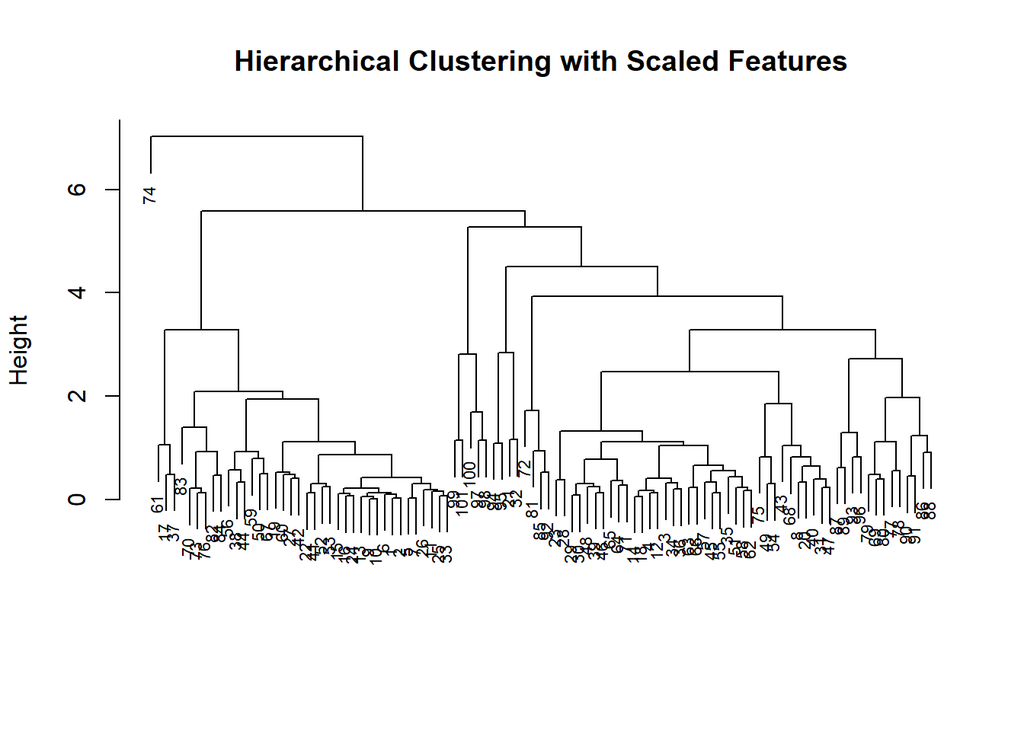

```r
plot(xsc.hc.complete, main = "Hierarchical Clustering with Scaled Features", xlab = "", sub = "", cex = 0.7)
```

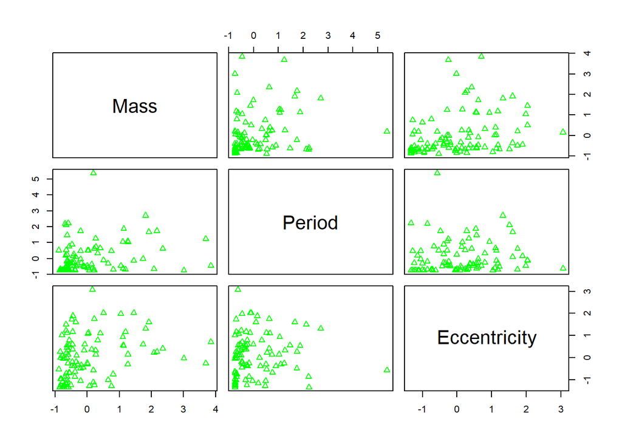

```r
pairs(data, pch=2, col="green")
```

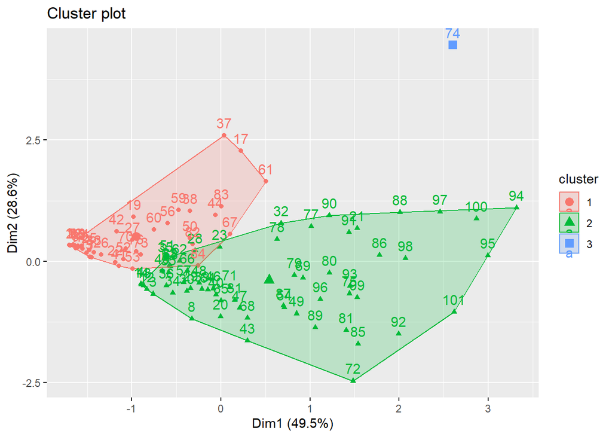

```r
sub_grp <- cutree(hc.complete, k = 3)
fviz_cluster(list(data = data, cluster = sub_grp))
```

### Using K means clustering with K=3, repeat process and compare conclusions

K-mean clustering is a technique used to partition a large dataset of n by n or n by m dimension into a small dimension by clustering the data variables into clusters. Observation in the data belongs to the cluster with the nearest mean.

```r
k_clusters <- kmeans(data, 3, nstart = 20)
k_clusters
```

```
## K-means clustering with 3 clusters of sizes 33, 54, 14
##
## Cluster means:
##          Mass      Period Eccentricity
## 1 -0.08620525 -0.03791475    1.0358846
## 2 -0.45734032 -0.28145496   -0.7374511
## 3  1.96722503  1.17498249    0.4027263
##
## Clustering vector:
##   [1] 2 2 2 2 2 2 2 1 2 2 2 2 2 2 2 2 2 2 2 1 1 2 1 2 2 2 2 2 1 1 1 1 2 1 2 2 2
##  [38] 2 1 1 2 2 1 2 2 1 1 1 1 2 2 2 2 1 2 2 2 2 2 2 2 2 2 1 1 2 2 1 1 2 1 1 2 3
##  [75] 1 2 1 1 1 1 1 2 2 2 1 3 1 3 1 3 3 1 3 3 3 3 3 3 3 3 3
##
## Within cluster sum of squares by cluster:
## [1] 42.37787 50.25975 50.94098
##  (between_SS / total_SS =  52.1 %)
##
## Available components:
##
## [1] "cluster"      "centers"      "totss"        "withinss"     "tot.withinss"
## [6] "betweenss"    "size"         "iter"         "ifault"
```

```r
k_clusters$cluster
```

```
##   [1] 2 2 2 2 2 2 2 1 2 2 2 2 2 2 2 2 2 2 2 1 1 2 1 2 2 2 2 2 1 1 1 1 2 1 2 2 2
##  [38] 2 1 1 2 2 1 2 2 1 1 1 1 2 2 2 2 1 2 2 2 2 2 2 2 2 2 1 1 2 2 1 1 2 1 1 2 3
##  [75] 1 2 1 1 1 1 1 2 2 2 1 3 1 3 1 3 3 1 3 3 3 3 3 3 3 3 3
```

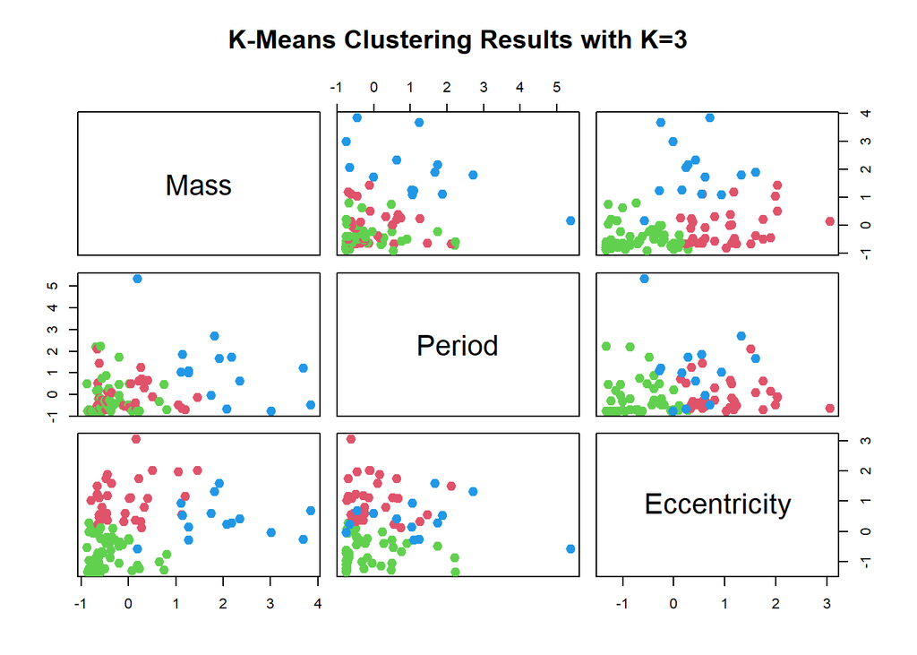

```r
plot(data, col = (k_clusters$cluster + 1), main = "K-Means Clustering Results with K=3", pch = 20, cex = 2)
```